# Virtual collaboration

# Panoply of technology

[figure not shown]

# Ease of use

- does it require dedicated software?
- does it require specific training?
- can you move easily across platforms, devices?

### Who are your users?

# Who controls content

## is it stored...

- ...locally for individuals?
- ...on a (trusted) shared server?
- ...on a commercial platform?

# Performance

- Are there size limits?
- Are there speed bottlenecks?
- Is reliability high enough?

# Other considerations...

- Open source or proprietary
- Portability
- Killer features

# Recap

- Ease of use
- Who controls content
- Open source or proprietary
- Performance
- Specific features

# Choosing your tool

[figure not shown]

# What are your needs?

- What is your content?
  - Ideas? Documents? Tasks? Data? Analyses? References?
- Asynchronous or synchronous?
- Online or offline?
- Individual copies? or shared?
- Free form and flexible, or highly structured?
- Ephemeral or durable?

# Email

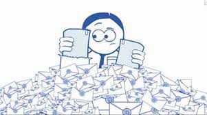

- Content not really shared
- Management burden imposed on each user

# Messaging, conversations

[figure not shown]

- IRC
- Twitter, Google+, Facebook, ResearchGate

# Video, screen sharing

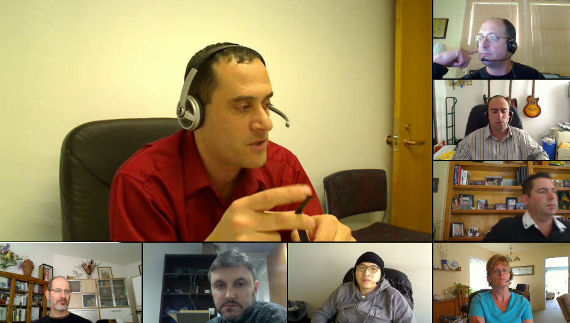

- Google+ Hangouts
- Skype
- Go To Meeting
- WebEx

# File sharing

[figure not shown]

- Dropbox
- BtSync
- Google Drive

# Version control systems

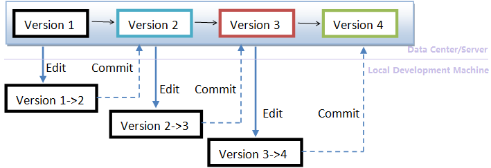

- Git
- Subversion

# Collaborative editing

[figure not shown]

- Etherpad
- Google Docs
- MediaWiki
- ...other wiki software

# Project Management

#### (typically: issue tracking, repo browser, wiki)

- Redmine, Trac, Jira
- Github, Google Code, Sourceforge

# Content management systems

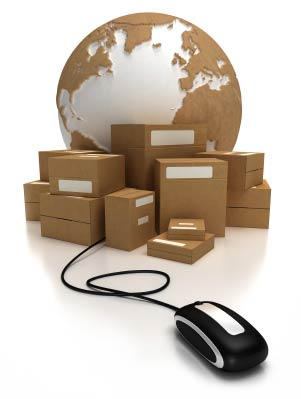

- Drupal
- WordPress
- Plone

# Data/artifact sharing

- KNB
- DataONE
- FigShare
- Dryad
- "The Cloud"

# Remote Computation

- Shell
- Grid engines
- Condor
- Globus
- Hadoop
- "The Cloud"

# Bibliographic

- Zotero
- Mendeley